# Supplementary Data 2

### 9. PCA stability

Here we assess the stability of the PCA components using subsamples

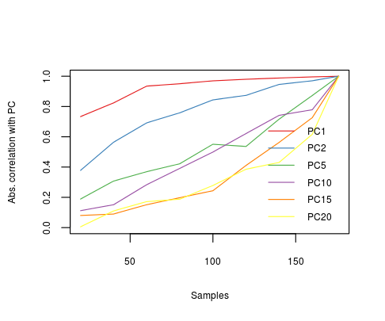

```r
set.seed(42)
s <- seq(20, ncol(geneExpr), 20)
c <- sapply(s, function(i) {
            rowMeans(abs(sapply(1:20, function(b){
                        y <-  prcomp(t(geneExpr[,sample(1:ncol(geneExpr),i)]))$rotation[,1:20];
                        diag(cor(pca$rotation[,1:20],y))})))
})
plot(c(s,176), c(abs(c[1,]),1), type='l', col=set1[1], xlab="Samples", ylab="Abs. correlation with PC", ylim=c(0,1))
j <- 1
for(i in c(2,5,10,15,20)){
    j <- j+1
    lines(c(s,176), c(abs(c[i,]),1), type='l', col=set1[j])
}
legend("bottomright", c("PC1","PC2","PC5","PC10","PC15","PC20"), col= set1[1:6], lty=1, bty="n")
```

## 3. Functional annotatition

In this section we will analyse the ENCODE annotation of those genomic regions that change in expression.

### 1. Load chromHMM data

```r
tmpf <- tempfile()
utils::download.file("http://hgdownload.cse.ucsc.edu/goldenpath/hg19/encodeDCC/wgEncodeBroadHmm/wgEncodeBroadHmmK562HMM.bed.gz", tmpf)
tmp <- read.table(tmpf, skip=1, sep="\t")
chromHMMK562 <- GRanges(sub("","",tmp$V1), IRanges(tmp$V2, tmp$V3), class=tmp$V4, col=factor(as.numeric(tmp$V9), labels=sapply(levels(tmp$V9), function(x) do.call("rgb", as.list(c(sapply(strsplit(x,","), as.numeric), maxColorValue = 255))))))
tmpf <- tempfile()
utils::download.file("http://hgdownload.cse.ucsc.edu/goldenpath/hg19/encodeDCC/wgEncodeBroadHmm/wgEncodeBroadHmmGm12878HMM.bed.gz", tmpf)
tmp <- read.table(tmpf, skip=1, sep="\t")
chromHMMGm12878 <- GRanges(sub("","",tmp$V1), IRanges(tmp$V2, tmp$V3), class=tmp$V4, col=factor(as.numeric(tmp$V9), labels=sapply(levels(tmp$V9), function(x) do.call("rgb", as.list(c(sapply(strsplit(x,","), as.numeric), maxColorValue = 255))))))

colChromHmm <- as.character(chromHMMK562$col[!duplicated(chromHMMK562$class)])
names(colChromHmm) <- (unique(chromHMMK562$class))
colChromHmm <- colChromHmm[order(as.numeric(sub("([0-9]+)_.+","\\1", names(colChromHmm))))]
colChromHmm[13] <- "#BBBBBB"
colChromHmm[14:15] <- "#DDDDDD"
```

### 2. Target genes as GRanges

```r
targetGenes <- GRangesList(sapply(colnames(testResults), function(j){
                    tmp <- na.omit(AnnotationDbi::select(org.Hs.eg.db, names(which(testResults[,j]<0)), c("ENTREZID","CHR","CHRLOC", "CHRLOCEND")))
                    GRanges(paste("chr",tmp$CHR,sep=""), shift(IRanges(ifelse(tmp$CHRLOC >0 , tmp$CHRLOC, -tmp$CHRLOCEND), width=10000),-5000), entrezid=tmp$ENTREZID)
                }))
targetGenesUp <- GRangesList(sapply(colnames(testResults), function(j){
                    tmp <- na.omit(AnnotationDbi::select(org.Hs.eg.db, names(which(testResults[,j]>0)), c("ENTREZID","CHR","CHRLOC", "CHRLOCEND")))
                    GRanges(paste("chr",tmp$CHR,sep=""), IRanges(abs(tmp$CHRLOC), abs(tmp$CHRLOCEND)), strand=ifelse(tmp$CHRLOC>0,"+","-"), entrezid=tmp$ENTREZID)
                }))
targetGenesDown <- GRangesList(sapply(colnames(testResults), function(j){
                    tmp <- na.omit(AnnotationDbi::select(org.Hs.eg.db, names(which(testResults[,j]<0)), c("ENTREZID","CHR","CHRLOC", "CHRLOCEND")))
                    GRanges(paste("chr",tmp$CHR,sep=""), IRanges(abs(tmp$CHRLOC), abs(tmp$CHRLOCEND)), strand=ifelse(tmp$CHRLOC>0,"+","-"), entrezid=tmp$ENTREZID)
                }))

sapply(targetGenesUp, function(x){
            y <- subsetByOverlaps(chromHMMK562,reduce(x),type="within")
            sapply(split(y, y$class), function(z) sum(width(z)))
        }) -> chromHmmUp
sapply(targetGenesDown, function(x){
            y <- subsetByOverlaps(chromHMMK562,reduce(x),type="within")
            sapply(split(y, y$class), function(z) sum(width(z)))
        }) -> chromHmmDown

tmp <- na.omit(AnnotationDbi::select(org.Hs.eg.db, rownames(geneExpr), c("CHR","CHRLOC","CHRLOCEND","ENTREZID")))
tmp <- tmp[tmp$CHR != "Un",]
tss <- sort(GRanges(paste("chr",tmp$CHR,sep=""), shift(IRanges(ifelse(tmp$CHRLOC >0 , tmp$CHRLOC, -tmp$CHRLOCEND), width=1000),-500), entrezid=tmp$ENTREZID))

t0 <- table(chromHMMK562[chromHMMK562 %over% reduce(tss)]$class)
o <- order(as.numeric(sub("_.+","",names(t0))))
```

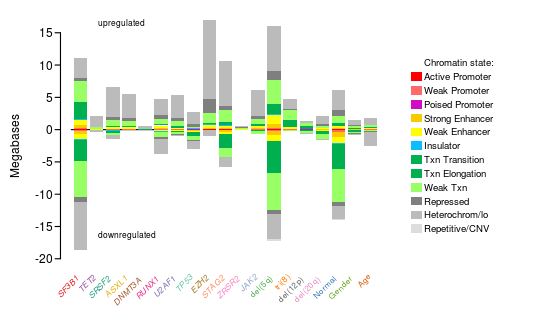

```r
par(bty="n", mgp = c(1.7,.33,0), mar=c(2.5,2.7,1,0)+.1, las=2, tcl=-.25)
plot(c(0, max(b)+1),c(0,0),xlim=c(0.5,33), ylab="Megabases",las=2, ylim=c(-20,15),xlab="", xaxt="n", type="l")
b <- barplot(chromHmmUp[o,]/1e6, col=colChromHmm, border=0.1,names.arg=rep("", ncol(chromHmmUp)), add=TRUE, yaxt="n")
barplot(-chromHmmDown[o,]/1e6, col=colChromHmm,add=TRUE, names.arg=rep("", ncol(chromHmmUp)), yaxt="n", border=NA)
rotatedLabel(x0=b, y0=rep(-20, ncol(chromHmmUp)), labels=colnames(chromHmmDown), cex=.7, srt=45, font=ifelse(grepl("[[:lower:]]", colnames(design))[-1], 1,3), col=colMutations)
u <- par("usr")
par(xpd=NA)
text(u[1]+2,u[4], "upregulated", pos=4, cex=.7)
text(u[1]+2,u[3]+5, "downregulated", pos=4, cex=.7)
n <- sub("[0-9]+ ","",gsub("_"," ",rownames(chromHmmDown)[o]))
legend("right", bty="n", fill=c(NA,colChromHmm[!duplicated(n)]), c("Chromatin state:",unique(n)), cex=.8, border=NA, y.intersp=.8, x.intersp=0.2 )
```

### 3. NIH roadmap histone modification data

We need the following bigwig files from GEO

```r
files <- dir("GSE19465", pattern="GSM48670", full.names = TRUE)
files
```

```
## [1] "GSE19465/GSM486702_BI.CD34_Primary_Cells.Input.CD34_39661.bw"
## [2] "GSE19465/GSM486704_BI.CD34_Primary_Cells.H3K27me3.CD34_39661.bw"
## [3] "GSE19465/GSM486706_BI.CD34_Primary_Cells.H3K27me3.CD34_39804.bw"
```

The above files have been downloaded from GEO (http://www.ncbi.nlm.nih.gov/geo/) into the directory `GSE19465` as wiggle tracks and converted into bigwig using wigToBigWig.pl for fast random access. The GSM identifiers will help find them.

```r
getTssEnrichment <- function(files, tss){
    sapply(files, function(f){
                wig <- import(f,"bigwig", which=tss)
                o <- findOverlaps(tss, wig)
                sapply(1:length(tss), function(h)
                            sum(wig[subjectHits(o)[queryHits(o)==h]]$score))
            })
}
tmp <- na.omit(AnnotationDbi::select(org.Hs.eg.db, rownames(geneExpr), c("CHR","CHRLOC","CHRLOCEND","ENTREZID")))
tmp <- tmp[tmp$CHR != "Un",]
tss <- sort(GRanges(paste("chr",tmp$CHR,sep=""), shift(IRanges(ifelse(tmp$CHRLOC >0 , tmp$CHRLOC, -tmp$CHRLOCEND), width=1000),-500), entrezid=tmp$ENTREZID)) ## All TSS of mapped genes +/- 500bp
h3k27 <- list(random = getTssEnrichment(files, tss[sample(length(tss), 1000)]),
        EZH2 = getTssEnrichment(files, tss[tss$entrezid %in% rownames(glm)[testResults[,"EZH2"]!=0]]),
        ASXL1 = getTssEnrichment(files, tss[tss$entrezid %in% rownames(glm)[testResults[,"ASXL1"]!=0]]))
```

Compute enrichment

```r
h3k27Enrichment <- sapply(h3k27, function(x)
            log10(rowSums(x[,2:3])/50 + .5)-log10(x[,1]/50+.5))
```

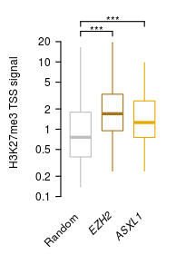

```r
par(bty="n", mgp = c(2,0.5,0), las=1, tcl=-.25, font.main=3, mar=c(3,3,1,0.5)+.1)
boxplot(h3k27Enrichment, yaxt="n",xaxt="n", boxwex=0.66, outline=FALSE, lty=1, outwex=0, staplewex=0, border=c("grey", colMutations[c("EZH2","ASXL1")]), log="", ylab="H3K27me3 TSS signal", ylim=c(-1,1.5))
a <- axTicks(side=2, axp=c(0.1,1,3),log=TRUE)
axis(side=2, at = log10(a), labels=a)
u <- par("usr")
rotatedLabel(1:3, rep(-1,3), c("Random", "EZH2", "ASXL1"), font=c(1,3,3))
p <- c(t.test(h3k27Enrichment$random, h3k27Enrichment$EZH2)$p.value,
        t.test(h3k27Enrichment$random, h3k27Enrichment$ASXL1)$p.value)
axis(3, at=c(1,2), labels=NA, tcl=0.25, line=-.5)
mtext(side=3, at=1.5,  sig2star(p[1]), line=-.85)
axis(3, at=c(1,3), labels=NA, tcl=0.25, line=0)
mtext(side=3, at=2,  sig2star(p[2]), line=-.35)
```

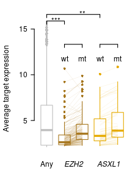

```r
par(bty="n", mgp = c(1.75,0.5,0), las=1, tcl=-.25, font.main=3, mar=c(1,2.5,1,0.5)+.1)
boxplot(glm$coefficients[,1],
        glm$coefficients[testResults[,"EZH2"]!=0,1],
        glm$coefficients[testResults[,"EZH2"]!=0,1]+glm$coefficients[testResults[,"EZH2"]!=0,"EZH2"],
        glm$coefficients[testResults[,"ASXL1"]!=0,1],
        glm$coefficients[testResults[,"ASXL1"]!=0,1] +  glm$coefficients[testResults[,"ASXL1"]!=0,"ASXL1"],
        xaxt="n", boxwex=0.66, outline=TRUE, lty=1, outwex=1, staplewex=0, pch=16, cex=.5,
        border=c("grey", colMutations[rep(c("EZH2","ASXL1"), each=2)]), log="", ylab="Average target expression", ylim=c(1,16))
segments(2,     glm$coefficients[testResults[,"EZH2"]!=0,1],
        3, glm$coefficients[testResults[,"EZH2"]!=0,1]+glm$coefficients[testResults[,"EZH2"]!=0,"EZH2"],
        col=paste(colMutations["EZH2"],"22",sep=""), lwd=.5,
)
segments(4,     glm$coefficients[testResults[,"ASXL1"]!=0,1],
        5, glm$coefficients[testResults[,"ASXL1"]!=0,1]+glm$coefficients[testResults[,"ASXL1"]!=0,"ASXL1"],
        col=paste(colMutations["ASXL1"],"22",sep=""), lwd=.5,
)
u <- par("usr")
axis(1, at=c(2,3), labels=c("wt","mt"), tcl=-0.25, line=-9, cex=.7)
axis(1, at=c(4,5), labels=c("wt","mt"), tcl=-0.25, line=-9, cex.lab=.3)
mtext(side=1,at=c(1, 2.5, 4.5), c("Any","EZH2","ASXL1"), line=-.5, font=c(1,3,3))
p <- c(t.test(glm$coefficients[,1],glm$coefficients[testResults[,"EZH2"]!=0,1])$p.value,
        t.test(glm$coefficients[,1],glm$coefficients[testResults[,"ASXL1"]!=0,1])$p.value)
axis(3, at=c(1,2), labels=NA, tcl=0.25, line=-.5)
s <- sig2star(p, breaks=10^c(-Inf,-3:0), labels=c("***","**","*",""))
mtext(side=3, at=1.5,  s[1], line=-.85, col=)
axis(3, at=c(1,4), labels=NA, tcl=0.25, line=0)
mtext(side=3, at=3,  s[2], line=-.35)
```

### 4. HB expression

The HGA and HGB loci show strong differences associated with mutations in SF3B1 and STAG2

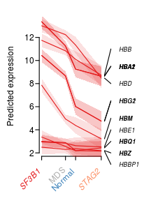

```r
par(bty="n", mgp = c(1.5,0.33,0), las=1, tcl=-.25, font.main=3, mar=c(3,2.5,1,3.5)+.1)
w <- intersect(unlist(AnnotationDbi::mget( grep("^hemoglobin,", Rkeys(org.Hs.egGENENAME), value=TRUE),revmap(org.Hs.egGENENAME))), rownames(glm))
x <- c(glmProjection[c("SF3B1","Normal","STAG2"),1],0)[c(1,4,2,3)]
y <- cbind(glm$coefficients[w,c("SF3B1","Normal","STAG2")], 0)[,c(1,4,2,3)] + glm$coefficients[w,"offset"]
plot(x,y[1,], pch=NA, xlab="", ylab="Predicted expression", ylim=range(y), xaxt="n")
u <- par("usr")
axis(side=1, at=x, labels=NA)
rotatedLabel(x, rep(u[3],4), c("SF3B1","MDS","Normal", "STAG2"), font=c(3,1,1,3), col=c(colMutations["SF3B1"],"#AAAAAA", colMutations[c("Normal","STAG2")]))
for(i in 1:nrow(y)){

    lines(x, y[i,], col=set1[1])
    o <- sqrt(c(glm$stdev.unscaled[w[i],c("SF3B1","Normal","STAG2")],0)[c(1,4,2,3)]^2 + glm$stdev.unscaled[w[i],1]^2)
    polygon(c(x,rev(x)), c(y[i,] + 2*o, rev(y[i,]) - 2*rev(o)), border=NA, col=paste(set1[1], "22",sep=""))
}
par(xpd=NA)
segments(x[4] + (u[2]-u[1])*.05, y[,4], x[4] + (u[2]-u[1])*.15, rank(y[,4]))
mtext(side=4, at=rank(y[,4]), text=select(org.Hs.eg.db, w, "SYMBOL")$SYMBOL, font=ifelse(select(org.Hs.eg.db, w, "CHR")$CHR==16, 4,3), las=2, cex=.7, line=1)
```

## 4. Clinical regression

```r
mdsSamples <- mdsData$GEOID[ix]
subs <- mdsData[ix, grep("SF3B1|TET2|SRSF2|ASXL1|DNMT3A|RUNX1|U2AF1|TP53|EZH2|IDH2|STAG2|ZRSR2|CBL|BCOR|NRAS|JAK2|CUX1|IDH1|KRAS|PHF6|EP300|GATA2|NPM1|MLL2|PTPN11|CREBBP|KIT|MPL|NF1|WT1|IRF1|RAD21|ATRX|CDKN2A|ETV6|KDM6A|CEBPA|FLT3|GNAS|PTEN|SH2B3|BRAF|CTNNA1", colnames(mdsData))] # oncogenic mutations
subs <- subs[,colSums(subs)>2]
```

### 1. Define variable categories

```r
Z <-  list()
Z$expression = scale(pca$x[mdsSamples,1:20])
Z$genetics = scale(subs+0, scale=FALSE)
Z$cytogenetics = scale(cytoImputed, scale=FALSE) #data[match(rownames(design), mds_clin$PDID),c("chr3","del5q","del7_7q","tri8","del11","del12","alt17q","tri19","del20q","complex")],
Z$geneticsExpression = cbind(Z$genetics,Z$expression)
Z$blood = scale(mdsData[ix,c("PB_cytopenia","plt_log","Haemoglobin","bm_blasts_logit","ring_sideroblasts_logit")])
Z$demographics = scale(mdsData[ix,c( "Gender", "Age")])
Z$clinical = cbind(Z$blood, Z$demographics)
Z$geneticsCytogenetics = cbind(Z$genetics, Z$cytogenetics)
Z$geneticsCytogeneticsExpression = cbind(Z$geneticsCytogenetics, Z$expression)
Z$expressionClinical = cbind(Z$expression, Z$clinical)
Z$geneticsClinical = cbind(Z$genetics, Z$clinical)
Z$geneticsExpressionClinical = cbind(Z$geneticsExpression, Z$clinical)
Z$all = cbind(Z$geneticsCytogenetics, Z$expression, Z$clinical)
```

### 2. Compute LASSO regression

```r
Y <- cbind(mdsData[ix,c("PB_cytopenia","plt_log","Haemoglobin","bm_blasts_logit","ring_sideroblasts_logit", "Gender", "Age")],
                (mdsData[ix,c("anc_log","ME_ratio", "Serum_ferritin" )]))
colnames(Y) <- c("Cytopenia", "Platelets","Haemoglobin","Bonemarrow blasts","Ringed sideroblasts","Gender","Age","Absolute neutrophil count","M:E ratio","Serum ferritin")
Y <- Y[,order(colnames(Y))]
X <- scale(Z$geneticsCytogeneticsExpression, scale=TRUE)
for(j in 1:ncol(X))
    X[is.na(X[,j]),j] <- mean(X[,j], na.rm=TRUE)
set.seed(42)
clinModels = lapply(Y, function(y){
            if (class(y) %in% c("numeric","integer")){
                if(all(y %in% c(0,1,NA)))
                    cv.glmnet(X[!is.na(y),], na.omit(y), family = "binomial", alpha=1, standardize=FALSE, nfolds=5)
                else if(all(y %in% c(0,20,NA)))
                    cv.glmnet(X[!is.na(y),], na.omit(y), family = "poisson", alpha=1, standardize=FALSE, nfolds=5)
                else
                    cv.glmnet(X[!is.na(y),], na.omit(y), family = "gaussian", alpha=1, standardize=FALSE, nfolds=5)
            }
            else if (class(y)=="factor")
                cv.glmnet(X[!is.na(y),], na.omit(y), family="multinomial",  alpha=1, standardize=FALSE, nfolds=5)
        })
```

#### Plot

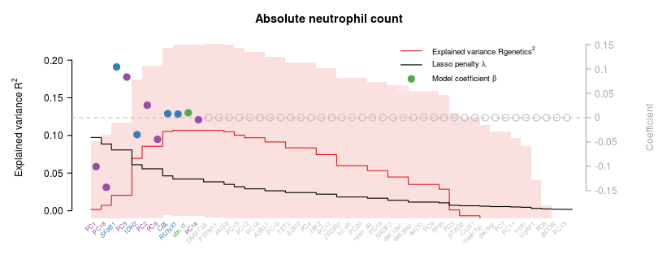

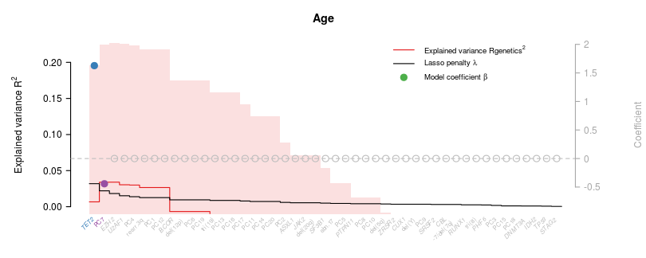

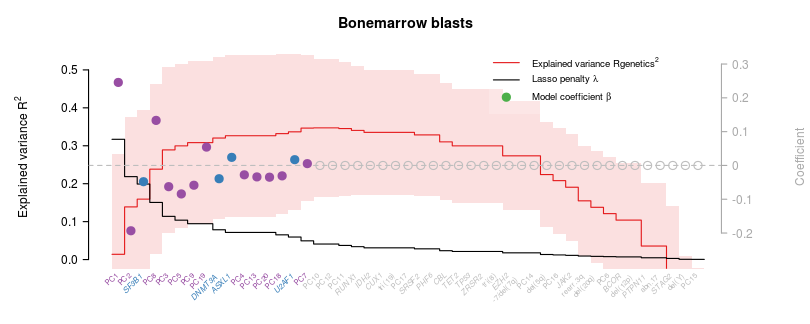

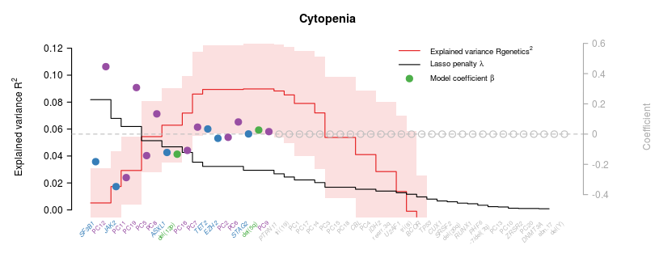

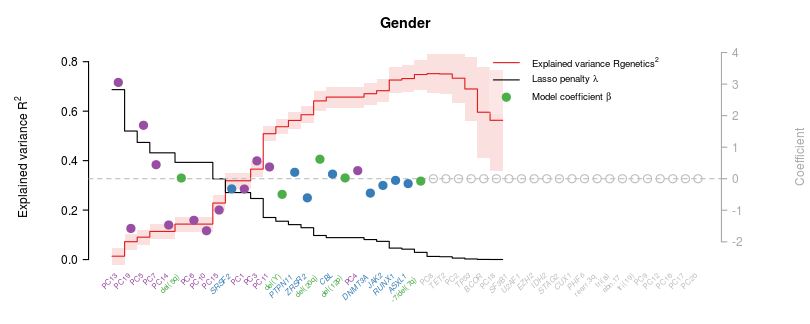

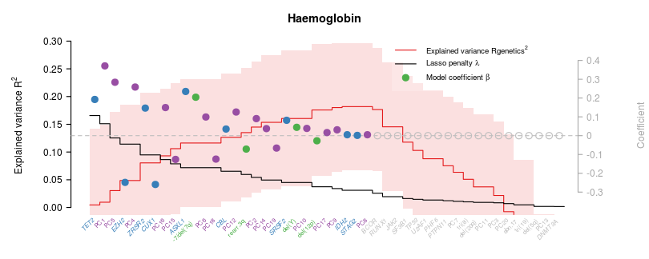

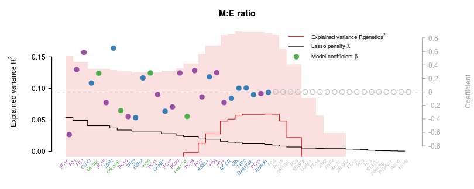

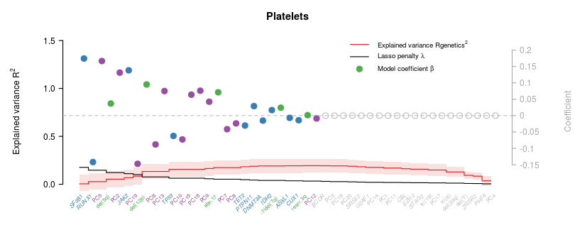

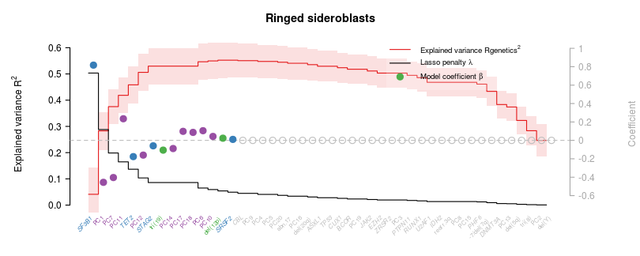

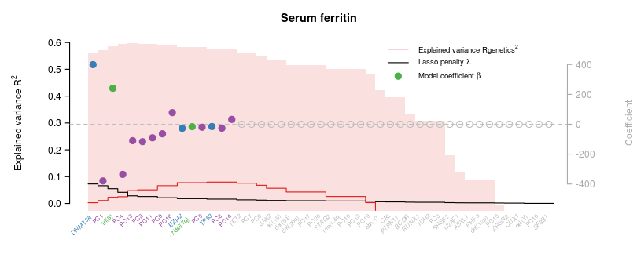

```r
par(bty="n", mgp = c(2.5,.5,0), mar=c(2.5,4,2,4)+.1, las=2, tcl=-.25)
i = 1
n <- colnames(Z$geneticsCytogeneticsExpression)
annot <- 1 + grepl("^[A-Z]",n) + grepl("PC",n)
names(annot) <- n
for(m in clinModels){
    plotcvnet(m, Z$geneticsCytogeneticsExpression, main=names(clinModels)[i],  col0="black", cex=1, simple.annot = annot, col=set1[c(3,2,4)])
    i = i+1
    legend("topright", col=c(set1[c(1,3)],"black")[c(1,3,2)], c(expression(paste("Explained variance ",Rgenetics^2)), expression(paste("Lasso penalty ",lambda)), expression(paste("Model coefficient ", beta))), box.lty=0, bg="#FFFFFF33", pch=c(NA,NA,19), lty=c(1,1,NA), cex=.8, pt.cex = 1)
}
```

#### Heatmap of GLMs

Compute a matrix with all coefficients as well as the R2

```r
j <- 0
z <- sapply(clinModels,function(x){
            j <<- j+1
            w <- which.min(x$cvm)
            c <- x$glmnet.fit$beta[,w]
            yj <- sapply(c("genetics","cytogenetics","expression"), function(i){
                        w <- colnames(Z[[i]])
                        X[,w] %*% c[w]
                    })
            cj <- rowSums(cov(yj))
            y <- Y[,j] - x$glmnet.fit$a0[w]
            covj <- colMeans((y-mean(y))*(yj - rep(colMeans(yj), each=nrow(yj))))
            r2 <- cj
            R2 <- 1 - x$cvm[w]/x$cvm[1]
            c(c, NA,  r2/sum(r2), R2=R2)
        })
m <- nrow(z) #ncol(Z$geneticsCytogeneticsExpression)
z[1:m,] <- pmin(z[1:m,],1)
z[1:m,] <- pmax(z[1:m,],-.999)
z[z==0] <- NA
```

These are the ranks

```r
r <- sapply(clinModels, function(x) rank(apply(x$glmnet.fit$beta,1, function(y) which(y!=0)[1]), ties="min"))
s <- sapply(clinModels, function(x) {
            w = which.min(x$cvm)
            w <- rev(which(x$cvm[1:w] > x$cvup[w]))[1] +1
            if(!is.na(w))
                sum(x$glmnet.fit$beta[,w]!=0)
            else
                0
        })
p <- sapply(clinModels, function(x) {w <- which.min(x$cvm); (1 - x$cvup[w]/x$cvm[1]) > 0 })
```

The explained variance R2

```r
R2 <- z[nrow(z) - 3:0,]
R2[is.na(R2)] <- 0
z <- z[-(nrow(z) - 0:4),]
z <- z[,ncol(z):1]
r <- r[,ncol(r):1]
```

Plot

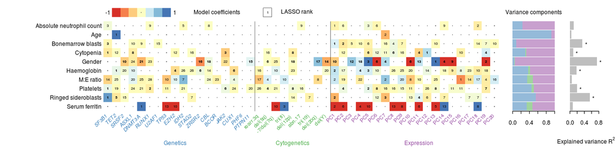

```r
layout(matrix(c(1,2,3),1,3), c(6.5,.75,.75), 2, TRUE)
par(bty="n", mgp = c(3,.5,0), mar=c(4,10,2,0)+.1, las=1, tcl=-.25, cex=1)
w <- TRUE#rev(c("ring_sideroblasts_logit","bm_blasts_logit","hb", "plt_log", "pb_cytopenia", "age","sex"))
image(y=1:ncol(z)-.5, x=1:nrow(z), z[,w], breaks=c(-2,seq(-1,1,l=51)), col=c("grey",colorRampPalette(brewer.pal(9,"RdYlBu"))(50)), xaxt="n", yaxt="n", xlab="", ylab="", ylim=c(0,10))
abline(v=c(18.5,27.5), lwd=0.5)
rotatedLabel(y0=rep(0.5,nrow(z)), labels=sub("_","/",rownames(z)), x0=1:nrow(z), font=c(rep(3,18),rep(1,nrow(z)-18)), col = set1[c(3,2,4)][annot], cex=0.9)
mtext(side=2, line=.2, text=colnames(z), las=2, at=1:ncol(z)-.5)
text(y=rep(1:ncol(z)-.5, each=nrow(r)), x=rep(1:nrow(r), ncol(z)), r[,w] * (0!=(z[1:nrow(r),w])), cex=0.66, font=ifelse(r <= rep(s[ncol(r):1], each=nrow(r)), 2,1))
points(y=rep(1:ncol(z)-.5, each=nrow(r)), x=rep(1:nrow(r), ncol(z)), pch=ifelse(is.na(z) | z==0, ".",NA))
mtext(side=1, at=9, "Genetics", col=set1[2], line=2.5 )
mtext(side=1, at=23, "Cytogenetics", col=set1[3], line=2.5 )
mtext(side=1, at=38, "Expression", col=set1[4], line=2.5 )
mtext(side=3, "Model coefficients", at = 14, line=0.5)
clip(-10,50,0,15)
image(y=dim(z)[2] + c(0.5,1.5), x=1+ 1:7 , matrix(seq(-0.99,1,l=7), ncol=1), breaks=c(-2,seq(-1,1,l=51)), col=c("grey",colorRampPalette(brewer.pal(9,"RdYlBu"))(50)), xaxt="n", yaxt="n", xlab="", ylab="", add=TRUE)
text(y=dim(z)[2]+1, x=c(1,9), c(-1,1))
points(y=11,x=5, pch=".")
rect(19.5,10.5,20.5,11.5, lwd=0.5)
text(20,11,1, cex=0.66)
text(21, 11, "LASSO rank", pos=4)
u <- par("usr")
par(bty="n", mgp = c(3,.5,0), mar=c(4,1,2,0)+.1, las=1, tcl=-.25)
plot(NA,NA, xlab="", ylab="", xaxt="n", yaxt="n", ylim=c(0,10), xlim=c(0,1), yaxs="i")
barplot(R2[1:3,ncol(R2):1], border=NA, col=paste(set1[c(2,3,4)],"88",sep=""), horiz=TRUE, names.arg=rep(NA,ncol(R2)), width=0.95, space=0.0525, add=TRUE)
mtext(side=3, "Variance components", line=.5)
par(bty="n", mgp = c(3,.5,0), mar=c(4,1,2,1)+.1, las=1, tcl=-.25)
plot(NA,NA, xlab="", ylab="", xaxt="n", yaxt="n", ylim=c(0,10), xlim=c(0,.9), yaxs="i")
barplot(R2[4,ncol(R2):1], border=NA, col="grey", horiz=TRUE, names.arg=rep(NA,ncol(R2)), width=0.95, space=0.0525, add=TRUE) -> b
points(R2[4,ncol(R2):1]+0.1,b, pch=ifelse(rev(p),"*",NA))
mtext(side=1, expression(paste("Explained variance ",R^2)), line=2.5)
```

#### Prediction of ringed sideroblasts

As an example of the LASSO fits, show the prediction vs. observations of the proportion of ringed sideroblasts.

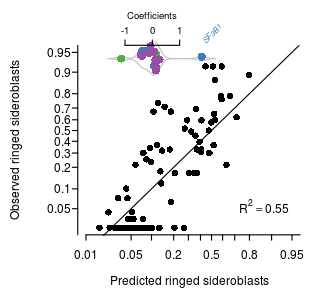

```r
par(bty="n", mgp = c(1.5,.33,0), mar=c(2.5,3.5,2,1)+.1, las=1, tcl=-.25)
w <- which(clinModels$`Ringed sideroblasts`$glmnet.fit$beta[,which.min(clinModels$`Ringed sideroblasts`$cvm)]!=0)
X <- scale(Z$geneticsCytogeneticsExpression, scale=TRUE)
for(j in 1:ncol(X))
    X[is.na(X[,j]),j] <- mean(X[,j], na.rm=TRUE)
set.seed(42)
#l <- lm(Y$`Ringed sideroblasts` ~ X[,w])
#y <- na.omit(Y$`Ringed sideroblasts`)
#x <- predict(l)
c <- clinModels$`Ringed sideroblasts`$glmnet.fit$beta[,which.min(clinModels$`Ringed sideroblasts`$cvm)]
y <- na.omit(Y$`Ringed sideroblasts`)
x <- X[-na.action(y),] %*% c + mean(y)
invlogit <- function(x) 1/(1+exp(-x))
plot(x, y, xaxt="n", yaxt="n", pch=16, cex=0.8, xlab="", ylab="", xlim=car::logit(c(0.01,0.95)), ylim=car::logit(c(0.025,0.95)))
title(xlab="Predicted ringed sideroblasts")
title(ylab="Observed ringed sideroblasts", line=2.5)
abline(0,1)
u <- par("usr")
par(xpd=NA)
#y <- l$coefficients[-1]+ l$coefficients[1]
y <- c[w] / apply(Z$geneticsCytogeneticsExpression,2,sd, na.rm=TRUE)[w] + mean(y)
u <- par("usr")
x0 <- rep(u[4]-0.5,length(y))
names(x0) <- names(y)
y0 <- u[4] + 0.05*(u[4]-u[3]) - rank(-y)/length(y) * (u[4]-u[3])/1.2
d <- density(y)
lines(d$x, d$y/2-0.5 +u[4], col="grey")
lines(d$x, -d$y/2-0.5+u[4], col="grey")
points(x=y, y=x0+violinJitter(y, magnitude=1)$y, pch=16, col=set1[c(3,2,4)][annot][w]) #annot[w]/10-0.2
w <- r[w,"Ringed sideroblasts"]
w <- "SF3B1"#names(w[w<=5])
rotatedLabel(y[w], x0[w], labels=(w), font=ifelse(grepl("PC", w),1,3), cex=.66, pos=3, col=set1[c(3,2,4)][annot[(w)]])
axis(at=-1:1 + mean(y), labels=-1:1, side=3, cex.axis=.8)
mtext(at=mean(y), line=1, side=3, "Coefficients", cex=.8)
text(u[2],u[3]+1, expression(paste(R^2==0.55)), pos=2)
par(xpd=FALSE)
car::probabilityAxis(side="left", axis.title = "")
car::probabilityAxis(side="below", axis.title = "")
```

## 5. Survival analysis

Here we analyse the influence of mutations, expression and blood counts on survival

### 1. Prepare data

```r
amlFreeSurvival <- Surv(time=mdsData$Survival_days, event=mdsData$Status)
amlFreeSurvival[!is.na(mdsData$AML_progression_days)] <- Surv(time=mdsData$AML_progression_days, event=mdsData$AML_status)[!is.na(mdsData$AML_progression_days)]
amlFreeSurvival[mdsData$AML_progression_days < 0 | mdsData$Survival_days < 0] <- NA
amlFreeSurvival <- amlFreeSurvival[ix]
amlFreeSurvival[,1] <- amlFreeSurvival[,1] /365*12 # Convert to months
```

#### Model

We use the following variant of the Cox proportional hazards model to estimate the survial models

```r
ecoxph <- function(X, surv, tol=1e-3, max.iter=50){
    if(class(X)=="data.frame")
        X = as.matrix(X)
    beta0 = rep(0,ncol(X))
    beta1 = rep(1,ncol(X))
    sigma2 = 1
    iter = 1
    while(max(abs(beta1-beta0))>tol& iter < max.iter){
        fit = coxph(surv ~ ridge(X, theta=1/sigma2, scale=FALSE))
        sigma2 = (1 + sum((fit$coefficients-mean(fit$coefficients))^2))/(ncol(X))
        beta0 = beta1
        beta1 = fit$coefficients
        #cat(beta1,"\n")
        #cat(sigma,"\n")
        iter = iter+1
    }
    fit$sigma2 = sigma2
    names(fit$coefficients) = colnames(X)
    return(fit)
}
```

This model uses a Gaussian prior on the coefficients. The variance of the prior is estimate by empirical Bayes. The shared prior introduces a ridge penalty on the parameters, which help stabilise the estimates.

#### Impute missing Z by mean..

```r
for(i in names(Z)){
    for(j in 1:ncol(Z[[i]])){
        Z[[i]][is.na(Z[[i]][,j]),j] <- mean(Z[[i]][,j], na.rm=TRUE)
    }
}
```

#### Concordance of models based on different covariates

Use five-fold cross validation

```r
set.seed(42)
concordanceCV = data.frame()
cv_ix = sample(1:5, length(mdsSamples), replace=TRUE)
for(i in unique(cv_ix)){
    c = lapply(Z, function(x) ecoxph(x[cv_ix!=i,], amlFreeSurvival[cv_ix!=i] ))
    p = mapply(function(x,y) as.matrix(x[cv_ix==i,]) %*% coef(y), Z, c)
    concordanceCV = rbind(concordanceCV, apply(-p,2, rcorr.cens, amlFreeSurvival[cv_ix==i])[1,])
}
colnames(concordanceCV) = names(Z)
colMeans(concordanceCV)
```

```
##                     expression                       genetics                   cytogenetics
##                         0.7561                         0.6770                         0.5039
##             geneticsExpression                          blood                   demographics
##                         0.7761                         0.6918                         0.6501
##                       clinical           geneticsCytogenetics geneticsCytogeneticsExpression
##                         0.7061                         0.6439                         0.7716
##             expressionClinical               geneticsClinical     geneticsExpressionClinical
##                         0.7578                         0.7080                         0.7605
##                            all
##                         0.7639
```

```r
ipss <- mdsData$ipss[ix]
hIpss <- rcorr.cens(-ipss,amlFreeSurvival)[1]
```

Barplots

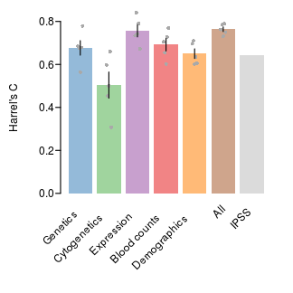

```r
par(bty="n", mgp = c(2,.33,0), mar=c(5,3,1,1)+.1, las=1, tcl=-.25, xpd=NA)
h <- concordanceCV[,c("genetics","cytogenetics","expression","blood","demographics","all")]
v <- sapply(h, sd)/sqrt(5)
colnames(h) <- ""
b <- barplot(c(colMeans(h),hIpss), border=NA, col=paste(c(set1[c(2,3,4,1,5,7)],"#BBBBBB"),"88", sep=""), las=2, ylim=c(0,0.8), ylab="Harrel's C", names.arg=rep("",7))
points(rep(b[-7], each=5) + seq(-.1,.1,l=5), unlist(h), pch=16, cex=.5, col="darkgrey")
segments(x0=b[-7], y0=colMeans(h)-v, y1=colMeans(h)+v)
rotatedLabel(b, rep(0,7), c("Genetics","Cytogenetics","Expression","Blood counts","Demographics","All","IPSS"))
```

Kaplan-Meier plots of risk terciles

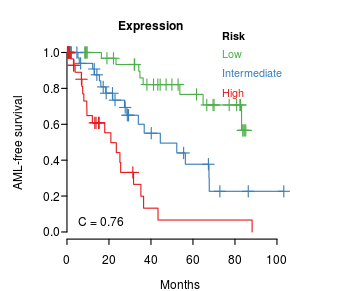

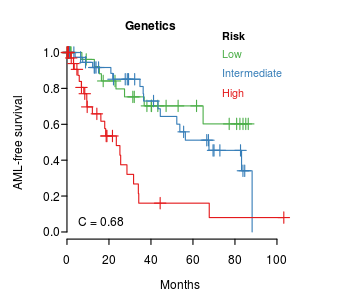

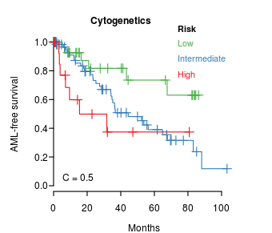

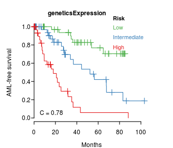

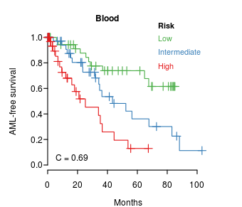

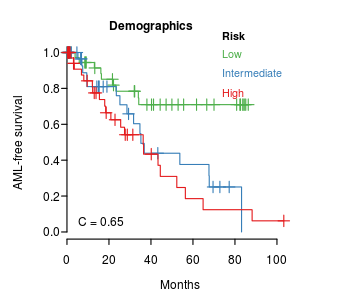

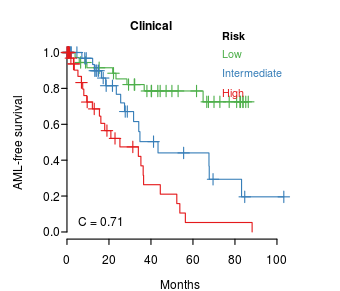

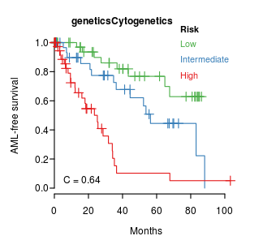

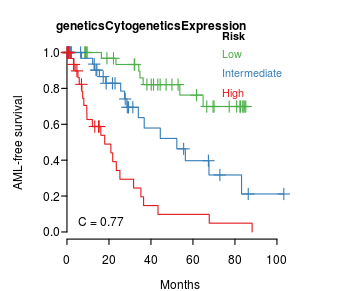

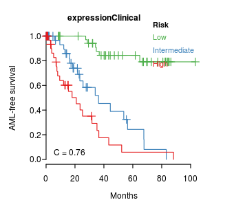

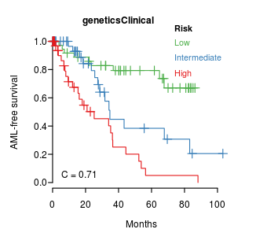

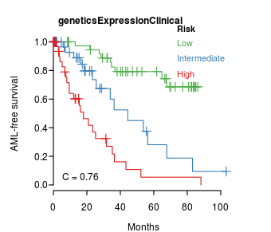

[1 more figures not shown]

```r
par(bty="n", mgp = c(1.9,.33,0), mar=c(2.3,3,2,2.1)+.1, las=1, tcl=-.25)
j <- 0
for(x in Z){
    j <- j +1
    c = sapply(1:5, function(i) coef(ecoxph(x[cv_ix!=i,],amlFreeSurvival[cv_ix!=i])))
    r = as.matrix(x) %*% rowMeans(c)
    plot(survfit(amlFreeSurvival ~ cut(r, quantile(r+runif(length(r), -0.01,0.01), seq(0,1,l=4), na.rm=TRUE), right=FALSE)), col = set1[3:1], xlab="", ylab="AML-free survival")
    title(xlab="Months", line=1.5)
    mtext(capitalize(names(Z)[j]), font=2, at=40, side=3, line=0.5)
    par(xpd=TRUE)
    legend(x=60, y=1.2, bty="n", "Risk", cex=0.9, text.font=2)
    legend(x=60, y=1.1, bty="n", text.col = set1[3:1], c("Low","Intermediate","High"), cex=0.9)
    text(x=0, y=0.05, paste("C =", round(colMeans(concordanceCV)[j],2)), cex=1, pos=4)
}
```

### 2. Risk contributions

Covariates once more

```r
X <-  data.frame(
        Genetics = Z$genetics,
        Cytogenetics = Z$cytogenetics,
        Expression= Z$expression,
        `Blood counts` = Z$blood,
        Demographics =  Z$demographics
)
```

#### Fit single model

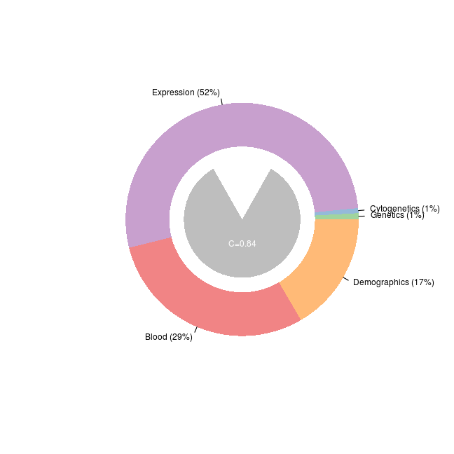

```r
groups <- sub("\\..+","",colnames(X))
model <- ecoxph(X, amlFreeSurvival)
index <- TRUE
r <- sapply(unique(groups[index]), function(x) {
            ix <- groups[index] == x
            as.matrix(X[,index][,ix, drop=FALSE]) %*% coef(model)[ix] #+ fullModel$sumX[,x] * fullModel$mu[x]
        })

c <- cov(r, use="complete")
x <-  colSums(c)/sum(c)#diag(c / sum(diag(c))) #
x <- x - sum(x[x < 0])
col0 <- c(paste(set1, "88", sep="")[c(3,2,4,1,5)], "grey")
pie(x, col=col0, border=NA, labels = paste(names(x), " (",round(100*x),"%)", sep=""))
polygon(cos(seq(0,2*pi,l=100))*.5, sin(seq(0,2*pi,l=100))*.5, col="white", border=NA)

C <- rcorr.cens(-rowSums(r), amlFreeSurvival)[1]
polygon(c(sin(seq(0,2*pi *C,l=100) +(1-C)*pi)*.4,0), c(cos(seq(0,2*pi *C,l=100)+(1-C)*pi)*.4,0), col="grey", border=NA)
text(0,-0.1, paste("C=",round(C,2), sep=""), col="white", pos=1)
```

#### Five-fold cross validation

It may be better to use cross-validation, especially for the estimate of concordance

```r
C <- NULL
y <- NULL
set.seed(42)
cv_ix = sample(1:5, length(mdsSamples), replace=TRUE)

for(i in 1:5){
    fit = ecoxph(X[cv_ix!=i,index],amlFreeSurvival[cv_ix!=i], tol=1e-6)
    c = coef(fit)
    C = c(C,rcorr.cens(-as.matrix(X[cv_ix==i,index][,groups!="Nuisance"]) %*% c[groups!="Nuisance"] , amlFreeSurvival[cv_ix==i])[1])
    r <- sapply(unique(groups[index]), function(x) {
                ix <- groups[index] == x
                as.matrix(X[cv_ix!=i,index][,ix, drop=FALSE]) %*% coef(fit)[ix] #+ fullModel$sumX[,x] * fullModel$mu[x]
            })

    c <- cov(r, use="complete")
    x <-  colSums(c)/sum(c)#diag(c / sum(diag(c))) #
    y <- rbind(y,x)
}
meanC <- mean(C)
x <- colMeans(y)
x <- colSums(c)/sum(c)
x <- x - sum(x[x<0])
pi <- base::pi
```

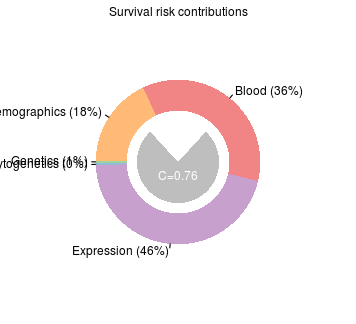

```r
par(bty="n", mgp = c(2,.33,0), mar=c(1,3,1,3)+.1, las=2, tcl=-.25)
pie(x, col=col0, border=NA, labels = paste(names(x), " (",round(100*x),"%)", sep=""), radius=.8, init.angle=179)
title(main="Survival risk contributions", font.main=1, cex.main=1)
polygon(cos(seq(0,2*pi,l=100))*.5, sin(seq(0,2*pi,l=100))*.5, col="white", border=NA)
polygon(c(sin(seq(0,2*pi *meanC,l=100) +(1-meanC)*pi)*.4,0), c(cos(seq(0,2*pi *meanC,l=100)+(1-meanC)*pi)*.4,0), col="grey", border=NA)
text(0,0, paste("C=",round(meanC,2), sep=""), col="white", pos=1)
```

### 3. Random Survival Forest

Here we compare the results of the previous section to a random survival forest

#### Fit model

```r
rsf <- rfsrc(Surv(time,status) ~ ., data=cbind(time=amlFreeSurvival[,1], status=amlFreeSurvival[,2], X) )
col=set1[c(3,2,4,1,5)]#  c(brewer.pal(8, "Dark2")[1:3], brewer.pal(8, "Set1")[2:1])
```

#### Variable importance

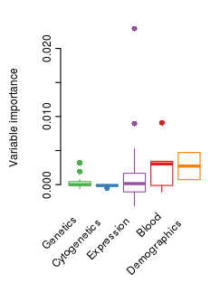

```r
par(bty="n", mgp = c(2,.33,0), mar=c(4,3,1,0.5)+.1, las=2, tcl=-.25, las=3, xpd=NA)
boxplot(rsf$importance ~ factor(groups, levels=unique(groups)), border= col, staplewex=0, pch=16, cex=0.75, ylab="Variable importance", lty=1, xaxt="n")
rotatedLabel(x0=1:5, y0=rep(-0.002,5), labels=unique(groups), srt=45)
```

The plot confirms the result that expression, blood counts, and clinical variables are most influental. Another plot

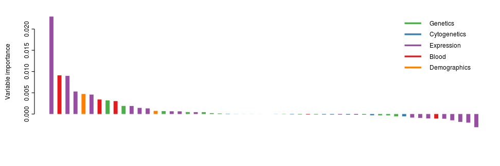

```r
par(bty="n", mgp = c(2,.33,0), mar=c(3,3,1,0.5)+.1, las=2, tcl=-.25, las=3, lend=1, xpd=NA)
o <- order(rsf$importance, decreasing = TRUE)
plot(rsf$importance[o], type="h", col=col[factor(groups, levels=unique(groups))[o]], ylab="Variable importance", xaxt="n", xlab="", lwd=7)
legend("topright", col=col, lty=1, unique(groups), bty="n", lwd=3)
```

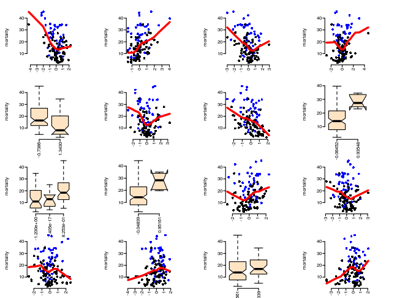

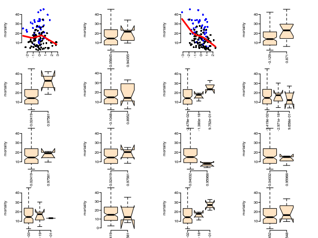

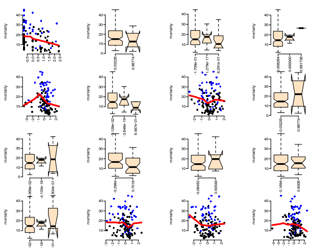

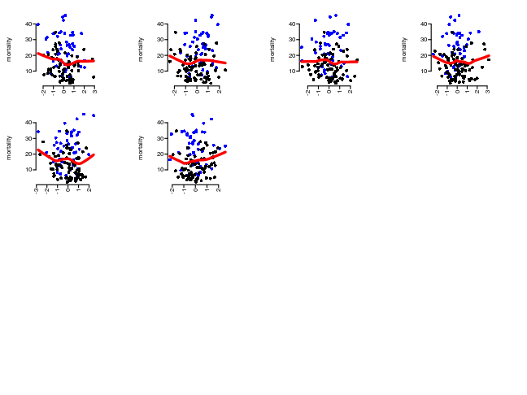

```r
par(bty="n", mgp = c(2,.33,0), mar=c(1,3,1,3)+.1, las=2, tcl=-.25)
plot.variable(rsf)
```

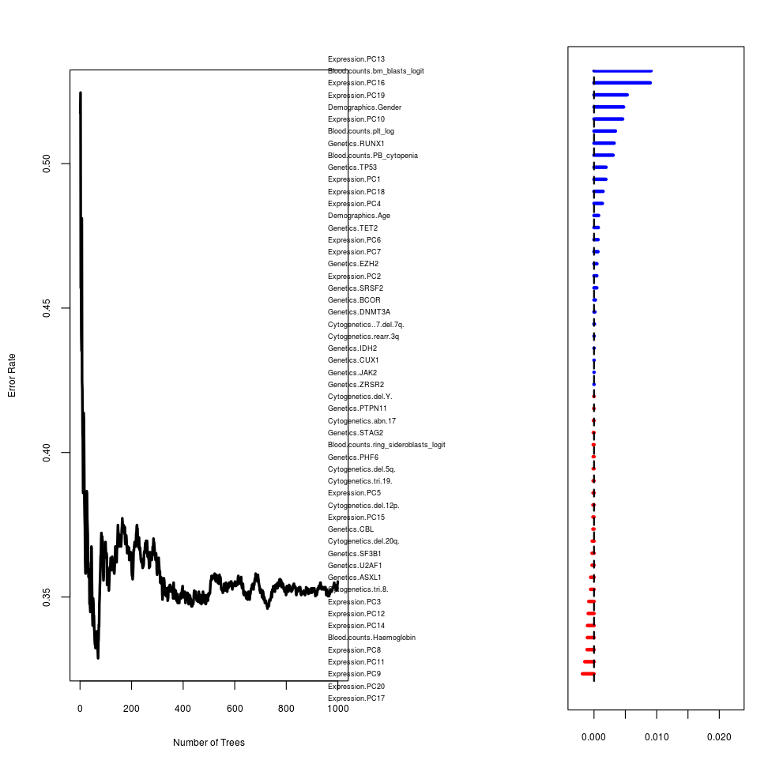

```
##
##                                        Importance   Relative Imp
## Expression.PC13                            0.0229         1.0000
## Blood.counts.bm_blasts_logit               0.0091         0.3968
## Expression.PC16                            0.0090         0.3916
## Expression.PC19                            0.0053         0.2310
## Demographics.Gender                        0.0047         0.2059
## Expression.PC10                            0.0046         0.1995
## Blood.counts.plt_log                       0.0034         0.1490
## Genetics.RUNX1                             0.0032         0.1398
## Blood.counts.PB_cytopenia                  0.0030         0.1326
## Genetics.TP53                              0.0019         0.0833
## Expression.PC1                             0.0019         0.0824
## Expression.PC18                            0.0014         0.0628
## Expression.PC4                             0.0013         0.0581
## Demographics.Age                           0.0007         0.0318
## Genetics.TET2                              0.0007         0.0298
## Expression.PC6                             0.0006         0.0283
## Expression.PC7                             0.0006         0.0273
## Genetics.EZH2                              0.0005         0.0202
## Expression.PC2                             0.0004         0.0193
## Genetics.SRSF2                             0.0004         0.0192
## Genetics.BCOR                              0.0002         0.0094
## Genetics.DNMT3A                            0.0001         0.0061
## Cytogenetics..7.del.7q.                    0.0001         0.0031
## Cytogenetics.rearr.3q                      0.0000         0.0010
## Genetics.IDH2                              0.0000         0.0006
## Genetics.CUX1                              0.0000         0.0006
## Genetics.JAK2                              0.0000         0.0003
## Genetics.ZRSR2                             0.0000         0.0002
## Cytogenetics.del.Y.                        0.0000        -0.0011
## Genetics.PTPN11                            0.0000        -0.0019
## Cytogenetics.abn.17                       -0.0001        -0.0042
## Genetics.STAG2                            -0.0001        -0.0052
## Blood.counts.ring_sideroblasts_logit      -0.0001        -0.0055
## Genetics.PHF6                             -0.0001        -0.0057
## Cytogenetics.del.5q.                      -0.0001        -0.0059
## Cytogenetics.tri.19.                      -0.0001        -0.0063
## Expression.PC5                            -0.0002        -0.0067
## Cytogenetics.del.12p.                     -0.0002        -0.0074
## Expression.PC15                           -0.0002        -0.0075
## Genetics.CBL                              -0.0002        -0.0076
## Cytogenetics.del.20q.                     -0.0003        -0.0124
## Genetics.SF3B1                            -0.0003        -0.0136
## Genetics.U2AF1                            -0.0003        -0.0139
## Genetics.ASXL1                            -0.0005        -0.0237
## Cytogenetics.tri.8.                       -0.0005        -0.0238
## Expression.PC3                            -0.0008        -0.0364
## Expression.PC12                           -0.0009        -0.0403
## Expression.PC14                           -0.0010        -0.0453
## Blood.counts.Haemoglobin                  -0.0011        -0.0461
## Expression.PC8                            -0.0011        -0.0482
## Expression.PC11                           -0.0015        -0.0642
## Expression.PC9                            -0.0018        -0.0807
## Expression.PC20                           -0.0020        -0.0885
## Expression.PC17                           -0.0031        -0.1358
```

```r
par(cex=0.75)
plot(rsf)
```